# TP 4 validacion cruzada

# Axel Fridman

```r
df = read.csv("datos_alquiler_crossvalidation.csv", stringsAsFactors = F)
df2 = read.csv("ar_properties.csv", stringsAsFactors = F)
```

1. Implemente una función que compute MAE:

```r
MAE=function(x,y){
  return(sum(abs(x-y))/length(x))
}
```

2. Implemente una función que compute PMAE:

```r
PMAE=function(x,y){
  return(sum(abs(x-y))/sum(abs(x)))
}
```

3. Considere el modelo que ajusta el precio en función de la superficie cubierta. Calcule el MAE y PMAE. Agregue la variable fondo y compare.

```r
modleloPrecioSupCub = lm(df$price~df$surface_covered)
modleloPrecioSupCubyFondo= lm(df$price~df$surface_covered+df$fondo)
```

```r
mae1 = MAE(df$price, predict(modleloPrecioSupCub))
pmae1=PMAE(df$price, predict(modleloPrecioSupCub))
mae2= MAE(df$price, predict(modleloPrecioSupCubyFondo))
pmae2=PMAE(df$price, predict(modleloPrecioSupCubyFondo))
```

El MAE del primer modelo es 3373.8504007 mientras que el MAE del segundo es ligeramente menor siendo 3318.7106127.

Por otro lado, los PMAE siendo una medida relativa a la escala tampoco varian mucho siendo respectivamente 0.1950315 y 0.1918441

4. Construya una función crossval(datos, modelo, n_obs, fun_error, n_muestras=10) para calcular el error promedio de predicción haciendo validación cruzada.

```r
crossval = function(datos, modelo, n_obs, fun_error, n_muestras=10){
  #¨df[sample(nrow(df), 3), ]
  errores = c()
  for(i in (1:n_muestras)){
    ind = sample(nrow(df),n_obs)

    datosEval = df[ind,]
    datosTrain = df[-ind, ]
    modeloActual = lm(modelo, data = datosTrain)


    #loPredecible = as.character(modelo[[2]])
    #print(datosEval$loPredecible)
    errores[i] = fun_error(datosEval$price, predict(modeloActual, datosEval))
  }
  #los errores obtenidos, el error promedio, su varianza, la formula
  #del modelo empleado y el modelo ajustado usando todos los datos.
  respuesta = list(errores, mean(errores), var(errores), modelo, lm(modelo, data = datos))
  return(respuesta)
}
```

5. Utilizando las funciones anteriores evalue el comportamiento de un modelo que ajuste el precio en función de la superficie cubierta utilizando validación cruzada. Use como función de error al PMAE

```r
crossval(df,formula('price~surface_covered'), 10, PMAE, 10)
```

```
[[1]]
 [1] 0.11169593 0.15142017 0.18241259 0.10432948 0.21099968 0.12714948 0.16194005 0.16490287 0.09985199 0.28148171

[[2]]
[1] 0.1596184

[[3]]
[1] 0.003121165

[[4]]
price ~ surface_covered

[[5]]

Call:
lm(formula = modelo, data = datos)

Coefficients:
    (Intercept)  surface_covered
         2871.7            277.2
```

Parece que es un buen ajuste, en una escala de menos del 30% del valor real.

6. Considere el modelo que ajusta el precio en función de la superficie cubierta. Explore como varía el error al usar valores de n_obs iguales a distintos porcentajes del tamaño del dataset, por ejemplo seq(1,100,5) y n_muestras=100. Grafique el error de validación cruzada en función de la cantidad de observaciones separadas. Qué le indica esto sobre la cantidad de observaciones que debe usar para validar el modelo?

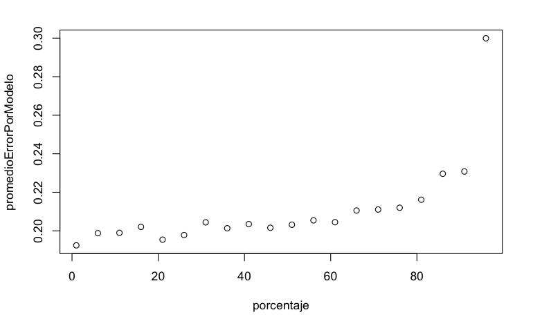

```r
porcentaje = seq(1,100,5)
promedioErrorPorModelo = c()
for(i in 1:length(porcentaje)){
  promedioErrorPorModelo[i] = crossval(df,formula('price~surface_covered'), porcentaje[i], PMAE, 100)[[2]]
}
plot(porcentaje, promedioErrorPorModelo)
```

Como norma general, en el grafico se ve que aumenta exponencialmente el error promedio a medida que nos acercamos con el numero de observaciones al total del dataset. Pero como tiene una parte de azar interesante por cada grafico ya que no controlamos el sample y hay saltitos cuando algun modelo justo se dio que era malo mas alla de la tendencia general, voy a “suavizarlo”. Como? Haciendo muchos modelos por cada porcentaje y tomando el promedio.

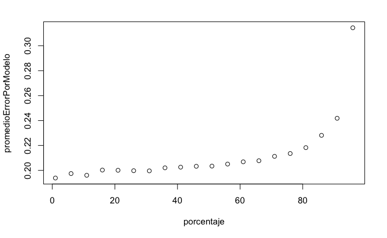

```r
porcentaje = seq(1,100,5)
promedioErrorPorModelo = c()
for(i in 1:length(porcentaje)){
  errorDeEstePorcentajeParticular = c()
  for(j in 1:10){
    errorDeEstePorcentajeParticular[j] = crossval(df,formula('price~surface_covered'), porcentaje[i], PMAE, 100)[[2]]
  }
  promedioErrorPorModelo[i] = mean(errorDeEstePorcentajeParticular)
}
plot(porcentaje, promedioErrorPorModelo)
```

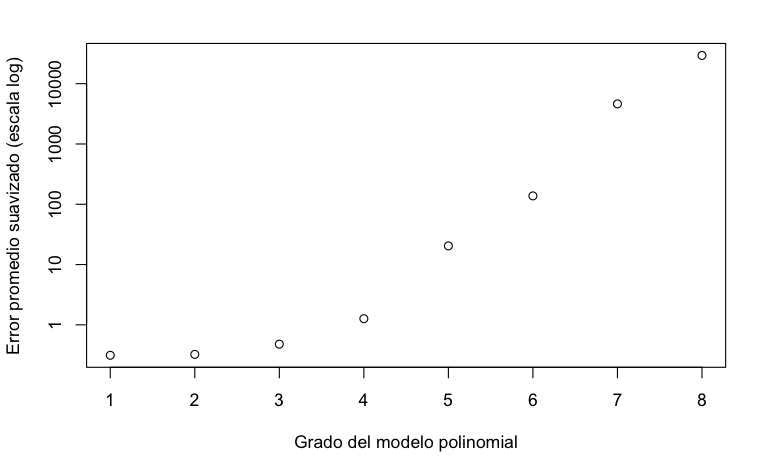

```r
modelosPotencia = c()
for (i in 1:8) {
  esc = paste('price~poly(fondo,', i, ')', sep="")
  modelosPotencia[i] = esc
}

errorModelos = c()
for(i in 1:8){
  errorDeEsteModeloParticular = c() #Suavizados los modelos
  for(j in 1:10){
    errorDeEsteModeloParticular[j] = crossval(df,modelosPotencia[i], round(length(df[,1])*0.2), PMAE, 20)[[2]]
  }
  errorModelos[i] = mean(errorDeEsteModeloParticular)
}
plot(1:8, errorModelos, log = 'y', xlab = 'Grado del modelo polinomial', ylab = 'Error promedio suavizado (escala log)')
```

El modelo con menor error de ajuste es el 1. Dicho esto, el crecimiento es incluso mas grande que exponencial simple, porque aun linealizando. El peor error lo tiene el de mayor grado, ya que el polinomio que me genera se memoriza los puntos donde entrena y es brutal la diferencia (debido a su alto crecimiento) con los puntos de evaluacion.